# Tugas Praktikum 4

Luthfia Aiman Hanin (G1401231064)

# **MA(2)**

## Proses MA(2)

Proses MA dapat dituliskan sebagai berikut:

$$y_{t} = c + e_t + \theta_{1}e_{t-1} + \theta_{2}e_{t-2} + \dots +
\theta_{q}e_{t-q} = c+{e_t+\sum_{i=1}^p \theta_ie_{t-i}}$$
Terlihat bahwa $e_t$, atau *white noise*, berperan penting dalam pembangkitan proses MA.

## Pembangkitan Proses MA(2)

Akan dicoba membangkitkan proses MA, yaitu MA(2) dengan $\theta_1 = 0.4$ dan $\theta_2 = 0.6$ sebanyak 300 observasi dan $c=0$.

```r
set.seed(123)
n <- 300
wn <- rnorm(n)
```

Nilai-nilai selanjutnya dapat dicari melalui *loop*. Bentuk loop dapat dilihat dari rumus MA(2) yang hendak dibangkitkan:

$$y_t = e_t + 0.4e_{t-1} + 0.6e_{t-2}$$

```r
#Manual
ma2 <- rep(0, 300)
for (t in 3:300) {
  ma2[t] <- wn[t] + 0.4*wn[t-1] + 0.6*wn[t-2]
}
```

Selain menggunakan cara di atas, pembangkitan proses MA(2) dapat dilakukan dengan fungsi `arima.sim()` sebagai berikut.

```r
#Dengan arima.sim
ma2.sim <- arima.sim(model = list(ma = c(0.4, 0.6)), n = n)
```

## Karakteristik MA(2)

### Plot Time Series

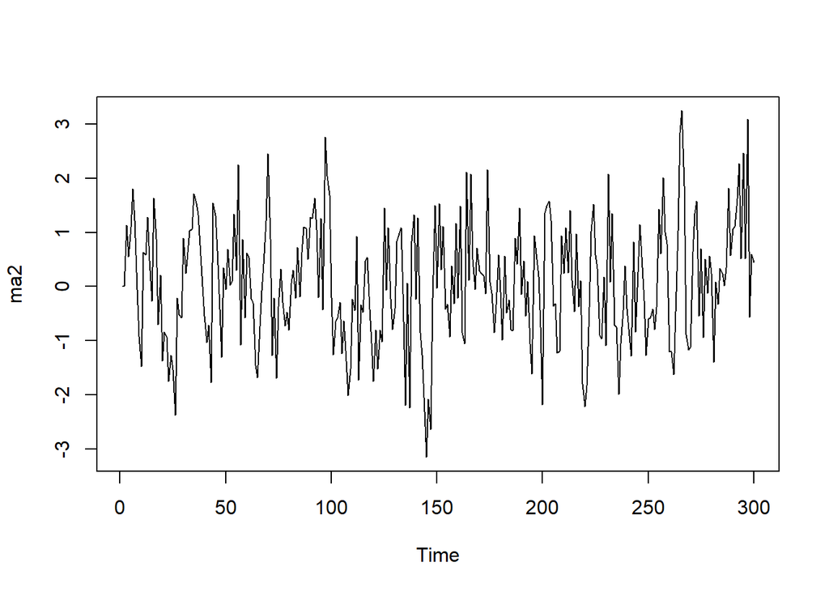

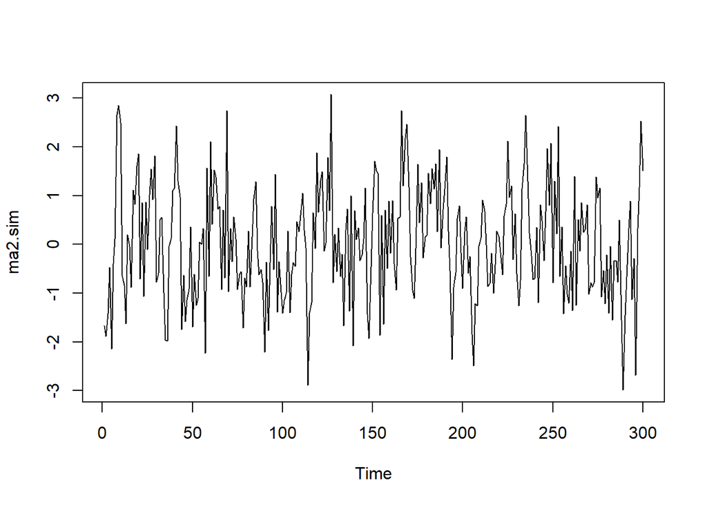

```r
ts.plot(ma2); ts.plot(ma2.sim)
```

Berdasarkan plot time series, terlihat bahwa data MA(2) yang dibangkitkan stasioner dalam rataan

### Plot ACF

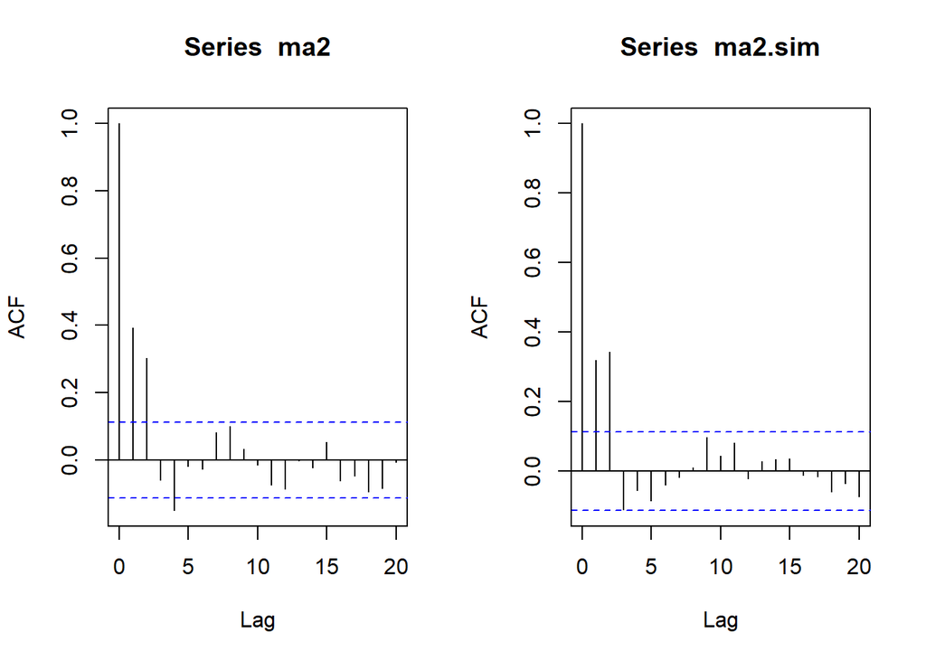

```r
par(mfrow = c(1, 2))
acf(ma2,lag.max = 20)
acf(ma2.sim, lag.max = 20)
```

Kedua plot menunjukkan pola ACF signifikan pada *lag ke-1 dan lag ke-2,* lalu setelah itu nilai autokorelasi turun mendekati nol. Data hasil bangkitan (manual maupun arima.sim) **stasioner**, karena ACF langsung *cut-off* pada lag ke-2.

### Plot PACF

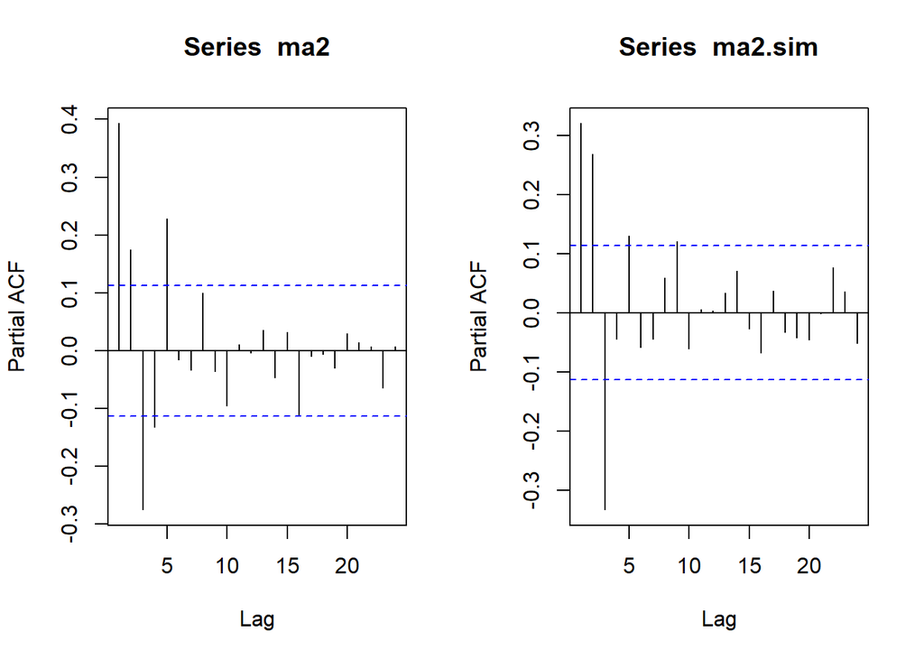

```r
par(mfrow = c(1, 2))
pacf(ma2)
pacf(ma2.sim)
```

Berdasarkan plot PACF tersebut, terlihat bahwa plot PACF cenderung *tails off* dan membentuk gelombang sinus.

### Plot EACF

```r
TSA::eacf(ma2)
```

```
## AR/MA
##   0 1 2 3 4 5 6 7 8 9 10 11 12 13
## 0 x x o x o o o o o o o  o  o  o
## 1 x x x x o o o o o o o  o  o  o
## 2 x x o x o o o o o o o  o  o  o
## 3 x x o o x o o o o o o  o  o  o
## 4 x x x o x o o o o o o  o  o  o
## 5 o x x x x o o o o o o  o  o  o
## 6 x o x x x o o o o o o  o  o  o
## 7 x x o x x o o o o o o  o  o  o
```

```r
TSA::eacf(ma2.sim)
```

```
## AR/MA
##   0 1 2 3 4 5 6 7 8 9 10 11 12 13
## 0 x x o o o o o o o o o  o  o  o
## 1 x x x o o o o o o o o  o  o  o
## 2 x x x x o o o o o o o  o  o  o
## 3 x x x o o o o o o o o  o  o  o
## 4 x x x o o x o o o o o  o  o  o
## 5 x x o o o x x o o o o  o  o  o
## 6 x x o o x x x x o o o  o  o  o
## 7 x x o x x x x x x o o  o  o  o
```

### Autokorelasi Antar Lag

#### Korelasi antara $Y_t$ dengan $Y_{t-1}$

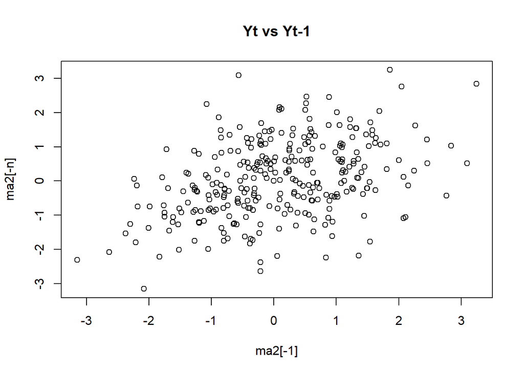

```r
plot(ma2[-1], ma2[-n], main="Yt vs Yt-1")
```

Berdasarkan scatterplot tersebut, terlihat bahwa terdapat hubungan positif antara $Y_t$ dengan $Y_{t-1}$. Hal ini sesuai dengan teori yang ada. Berikut adalah nilai korelasi $Y_t$ dengan $Y_{t-1}$ data bangkitan:

```r
cor(ma2[-1],ma2[-n])
```

```
## [1] 0.393034
```

#### Korelasi antara $Y_t$ dengan $Y_{t-2}$

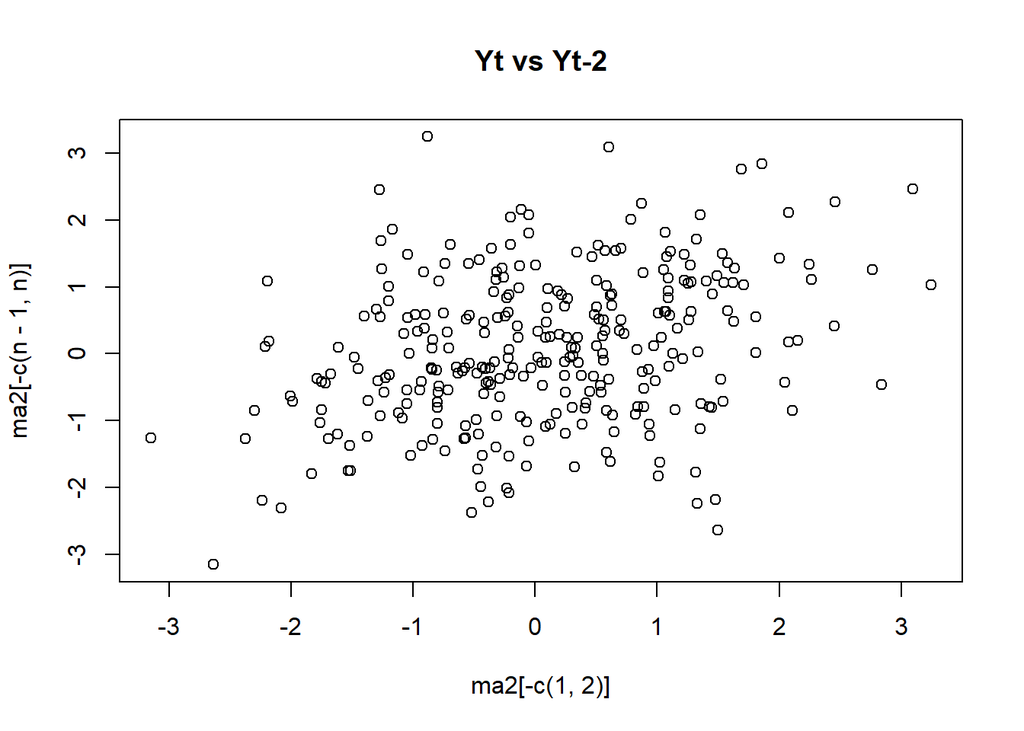

```r
plot(ma2[-c(1,2)], ma2[-c(n-1,n)], main="Yt vs Yt-2")
```

Berdasarkan scatterplot tersebut, terlihat bahwa terdapat hubungan yang positif yang lebih lemah antara $Y_t$ dengan $Y_{t-2}$. Berikut adalah nilai korelasi $Y_t$ dengan $Y_{t-2}$ data bangkitan:

```r
cor(ma2[-c(1,2)],ma2[-c(n-1,n)])
```

```
## [1] 0.3023042
```

Korelasi antara $Y_t$ dengan $Y_{t-2}$ dari hasil simulasi mendekati perhitungan teoritis, dengan menggunakan rumus dari penurunan definisi yaitu:

$$\rho_2=\frac{\gamma_{2}}{\gamma_{0}}=\frac{\theta_{2}}{1+(\theta_{1})^2+(\theta_{2})^2}=\frac{(0.6)}{1+(0.4)^2+(0.6)^2}=0.39$$

#### Korelasi antara $Y_t$ dengan $Y_{t-3}$

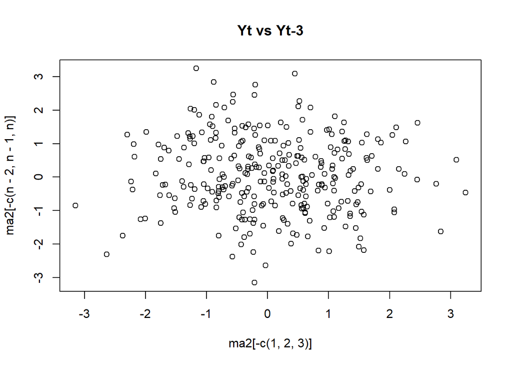

```r
plot(ma2[-c(1,2,3)], ma2[-c(n-2,n-1,n)], main="Yt vs Yt-3")
```

Berdasarkan scatterplot tersebut, terlihat bahwa terdapat hubungan yang negatif lemah antara $Y_t$ dengan $Y_{t-3}$. Berikut adalah nilai korelasi $Y_t$ dengan $Y_{t-3}$ data bangkitan:

```r
cor(ma2[-c(1,2,3)],ma2[-c(n-2,n-1,n)])
```

```
## [1] -0.0591205
```

Korelasi antara $Y_t$ dengan $Y_{t-3}$ hasil simulasi mendekati teori yang ada dimana $\rho_{k}=0$ untuk $k=3,4,\dots$

# **AR(2)**

## Proses AR(2)

Proses AR dapat dituliskan sebagai berikut:

$$y_{t} = c + e_t + \phi_{1}Y_{t-1} +
\phi_{2}Y_{t-2} + \dots + \phi_{q}Y_{t-q} = c+{e_t+\sum_{i=1}^p
\phi_iY_{t-i}}$$
Terlihat bahwa $Y_t$ berperan penting dalam pembangkitan proses AR.

## Pembangkitan Proses AR(2)

Akan dicoba membangkitkan proses AR, yaitu AR(2) dengan $\phi_1 = 0.5$ dan $\phi_2 = 0.2$ sebanyak 300 observasi dan $c=0$.

```r
set.seed(123)
n <- 300
wn <- rnorm(n)
```

Nilai-nilai selanjutnya dapat dicari melalui *loop*. Bentuk loop dapat dilihat dari rumus AR(2) yang hendak dibangkitkan:

$$Y_t = e_t+0.5Y_{t-1}+0.2Y_{t-2}$$

```r
# Manual
ar2 <- rep(0,n)
for (t in 3:n) {
  ar2[t] <- 0.5*ar2[t-1] + 0.2*ar2[t-2] + wn[t]
}
```

Selain menggunakan cara di atas, pembangkitan proses AR dapat dilakukan dengan fungsi `arima.sim()` sebagai berikut.

```r
ar2.sim <- arima.sim(model = list(ar = c(0.5, 0.2)), n = n)
```

## Karakteristik AR(2)

### Plot Time Series

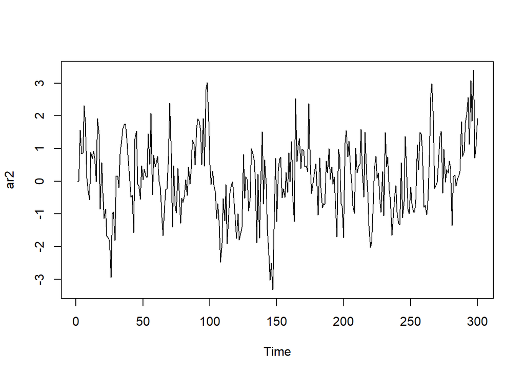

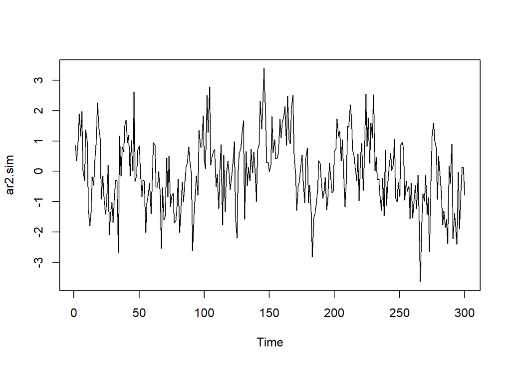

```r
ts.plot(ar2); ts.plot(ar2.sim)
```

Berdasarkan plot time series tersebut terlihat bahwa data cenderung stasioner pada rataan

### Plot ACF

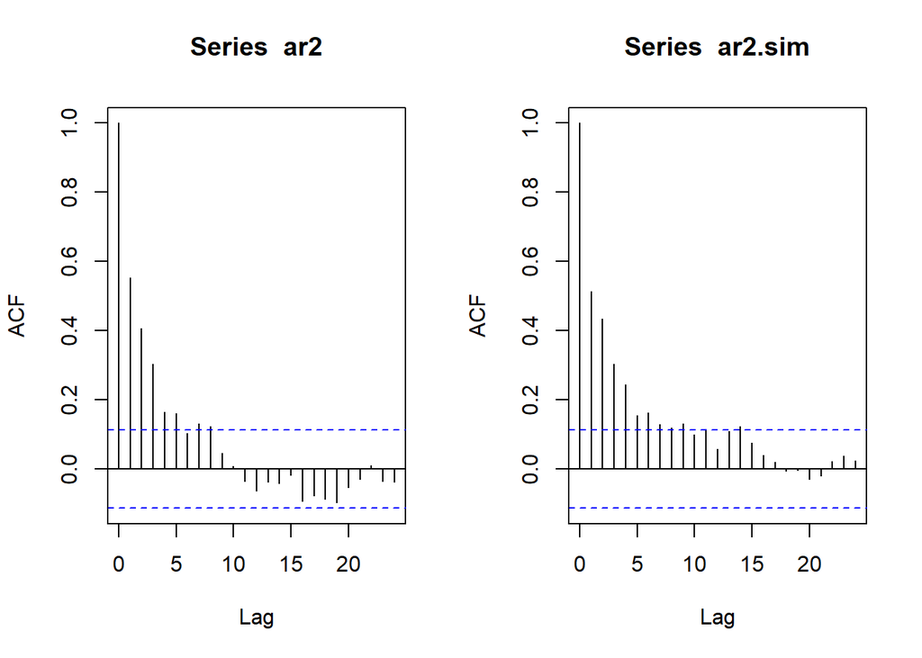

```r
par(mfrow = c(1, 2))
acf(ar2)
acf(ar2.sim)
```

Berdasarkan plot ACF tersebut terlihat bahwa plot ACF cenderung *tails off* dan cenderung membentuk pola grafik sinus

### Plot PACF

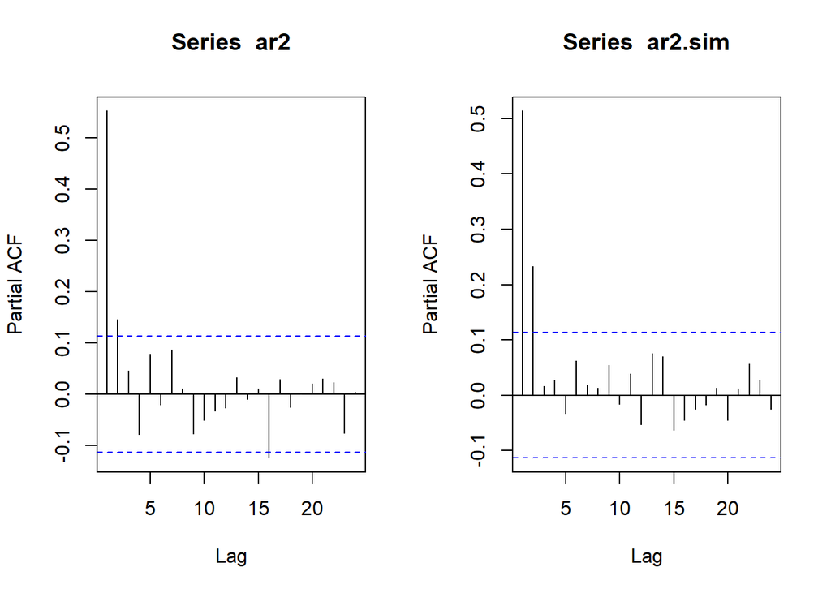

```r
par(mfrow = c(1, 2))
pacf(ar2)
pacf(ar2.sim)
```

Berdasarkan plot PACF tersebut, terlihat bahwa plot PACF *cuts off* pada lag kedua, sejalan dengan teori yang menunjukkan bahwa data **stasioner**. Sesuai dengan teori pula, AR(2) dikatakan stastioner jika memenuhi 3 syarat:

$$\phi_{1}+\phi_{2}<1, \:\phi_{2}-\phi_{1}<1, \:dan
\:|\phi_{2}|<1$$

AR(2) dengan $\phi_1 = 0.5$ dan $\phi_2 = 0.2$ **memenuhi seluruh syarat** tersebut, sehingga data ini dapat dikatakan **stasioner**.

### Plot EACF

```r
TSA::eacf(ar2)
```

```
## AR/MA
##   0 1 2 3 4 5 6 7 8 9 10 11 12 13
## 0 x x x x x o x x o o o  o  o  o
## 1 x o o x o o o o o o o  o  o  o
## 2 x o o o o o o o o o o  o  o  o
## 3 x o o o o o o o o o o  o  o  o
## 4 x o o o o o o o o o o  o  o  o
## 5 x x o o o o o o o o o  o  o  o
## 6 x x o x x o o o o o o  o  o  o
## 7 x x o x x o x o o o o  o  o  o
```

```r
TSA::eacf(ar2.sim)
```

```
## AR/MA
##   0 1 2 3 4 5 6 7 8 9 10 11 12 13
## 0 x x x x x x x x x o o  o  o  x
## 1 x o o o o o o o o o o  o  o  o
## 2 o x o o o o o o o o o  o  o  o
## 3 x o o o o o o o o o o  o  o  o
## 4 x x o x o o o o o o o  o  o  o
## 5 x x x o o o o o o o o  o  o  o
## 6 x o x x o o o o o o o  o  o  o
## 7 x o x x x o o o o o o  o  o  o
```

### Autokorelasi Antar Lag

#### Korelasi antara $Y_t$ dengan $Y_{t-1}$

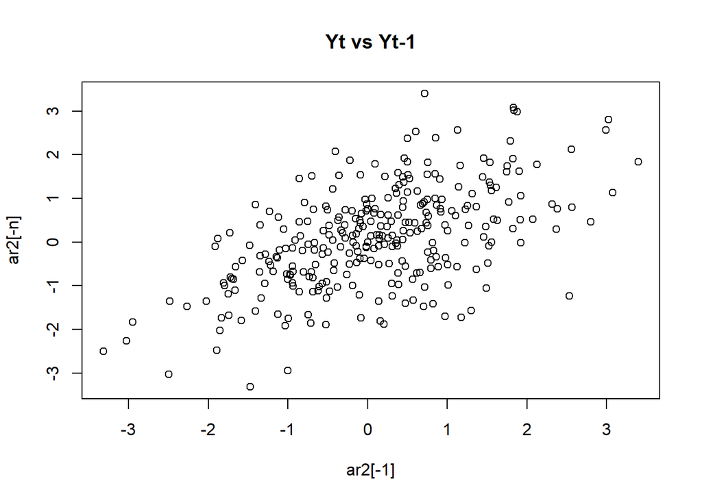

```r
plot(ar2[-1], ar2[-n], main="Yt vs Yt-1")
```

Berdasarkan scatterplot tersebut, terlihat bahwa terdapat hubungan positif antara $Y_t$ dengan $Y_{t-1}$. Hal ini sesuai dengan teori yang ada

```r
cor(ar2[-1],ar2[-n])
```

```
## [1] 0.5549983
```

Korelasi antara $Y_t$ dengan $Y_{t-1}$ dari hasil simulasi mendekati perhitungan teoritis, dengan menggunakan rumus dari penurunan definisi yaitu:

$$\rho_1=\frac{\gamma_{1}}{\gamma_{0}}=\frac{\phi_{1}}{1-\phi_{2}}=\frac{0.5}{1-0.2}=0.625$$

#### Korelasi antara $Y_t$ dengan $Y_{t-2}$

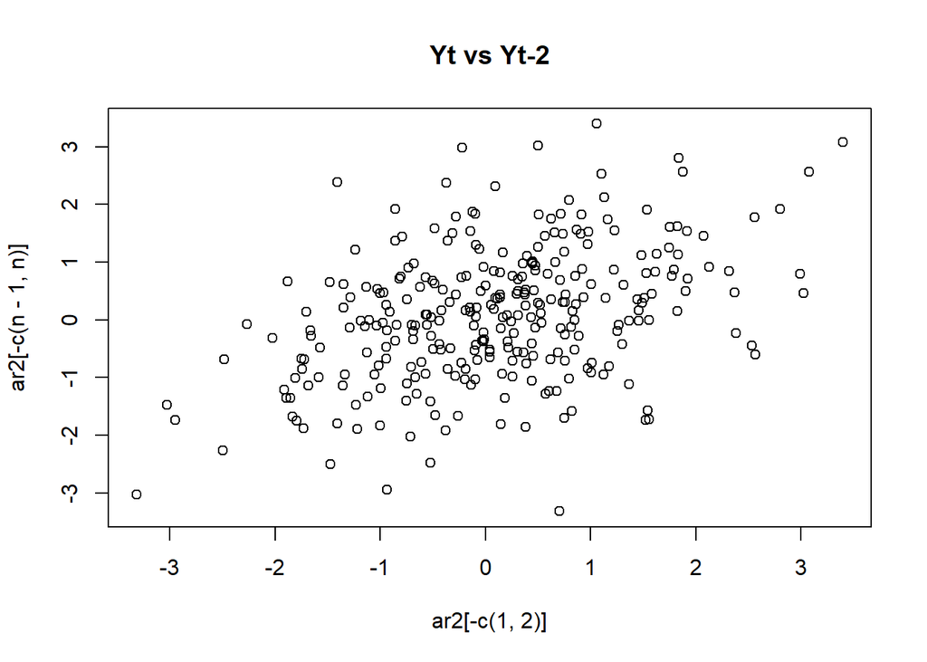

```r
plot(ar2[-c(1,2)], ar2[-c(n-1,n)], main="Yt vs Yt-2")
```

Berdasarkan scatterplot tersebut, terlihat bahwa terdapat hubungan positif antara $Y_t$ dengan $Y_{t-2}$. Hal ini sesuai dengan teori yang ada

```r
cor(ar2[-c(1,2)],ar2[-c(n-1,n)])
```

```
## [1] 0.4088021
```

Korelasi antara $Y_t$ dengan $Y_{t-2}$ dari hasil simulasi mendekati perhitungan teoritis, dengan menggunakan rumus dari penurunan definisi yaitu:

$$\rho_2=\frac{\gamma_{2}}{\gamma_{0}}=\phi_{1}\rho_{1}+\phi_{2}=0.5(0.625)+0.2=0.51$$

#### Korelasi antara $Y_t$ dengan $Y_{t-3}$

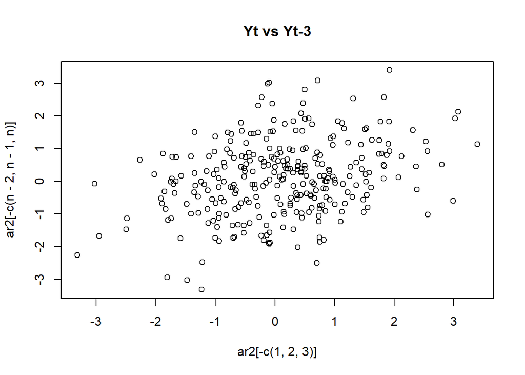

```r
plot(ar2[-c(1,2,3)], ar2[-c(n-2,n-1,n)], main="Yt vs Yt-3")
```

Berdasarkan scatterplot tersebut, terlihat bahwa terdapat hubungan positif yang lebih lemah antara $Y_t$ dengan $Y_{t-3}$. Hal ini sesuai dengan teori yang ada

```r
cor(ar2[-c(1,2,3)],ar2[-c(n-2,n-1,n)])
```

```
## [1] 0.30659
```

# **ARMA(2,2)**

## Fungsi pembangkitan ARMA(2,2)

Bentuk umum data berpola ARMA:

$$y_{t} = c + \sum_{i=1}^p \phi_{i}y_{t-i} + \sum_{j=1}^q e_{t-j}+ e_{t}$$

Dari prinsip ini, dapat dibuat fungsi umum untuk membangkitkan data ARMA. Input dari fungsi adalah jumlah data yang hendak dibangkitkan, koefisien MA, dan koefisien AR

```r
arma.sim <- function(n, macoef, arcoef){
  manum <- length(macoef)
  arnum <- length(arcoef)
  stopifnot(manum < n & arnum < n)

  wn <- rnorm(n, sd = 0.5)
  init <- max(manum, arnum)

  arma <- wn[1:init]
  for(i in {init+1}:n){
   mastart <- i - manum
   maend <- i-1
   arstart <- i - arnum
   arend <- i-1
   arma[i] <- sum(arcoef * arma[arstart:arend]) + sum(macoef * wn[mastart:maend])  + wn[i]
   }
  return(arma)
}
```

Akan dicoba membangkitkan proses ARMA, yaitu AR(2,2) dengan $\theta_{1}=0.4$ dan $\theta_{2}=0.6$ serta $\phi_1 = 0.5$ dan $\phi_2 = 0.2$ sebanyak 300 observasi dan $c=0$.

```r
#ARMA (2,2)
arma22 <- arma.sim(300, macoef = c(0.4, 0.6), arcoef = c(0.5, 0.2))
```

Pembangkitan ARMA(2,2) juga dapat dilakukan dengan fungsi `arima.sim` sebagai berikut.

```r
arma22.sim <- arima.sim(model = list(order = c(2,0,2),
                        ar = c(0.5, 0.2), ma = c(0.4, 0.6)), n=300)
```

## Karakteristik ARMA(2,2)

### Plot Time Series

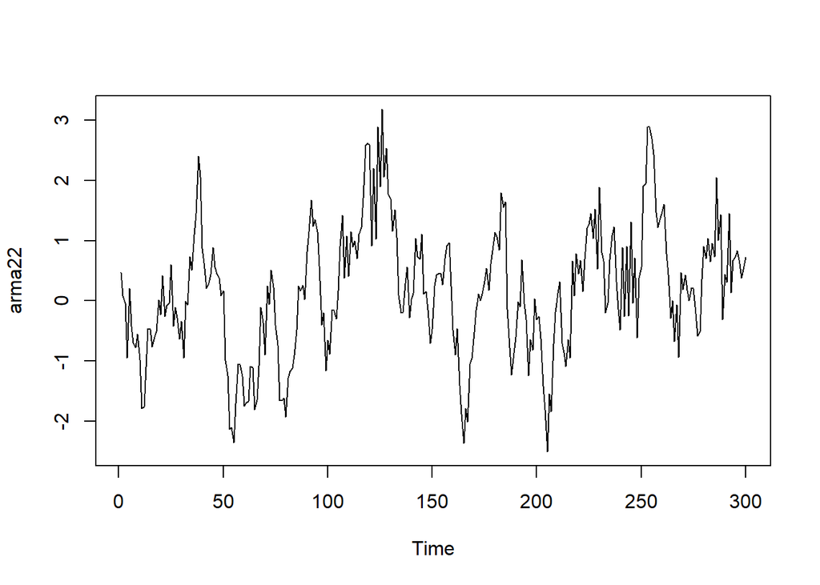

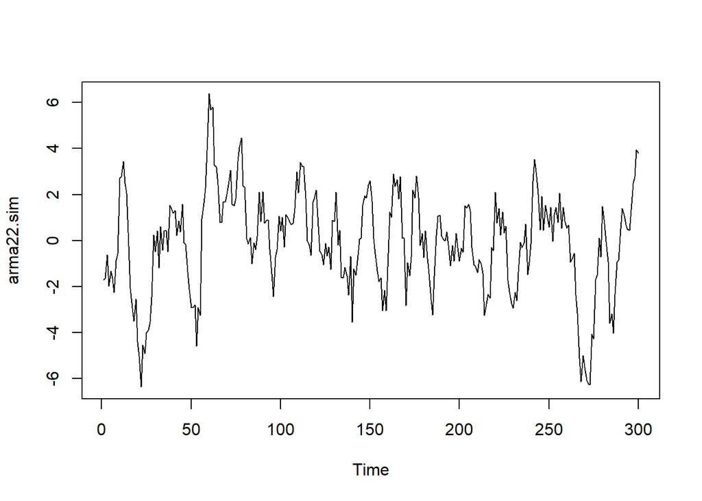

```r
ts.plot(arma22); ts.plot(arma22.sim)
```

Berdasarkan plot time series tersebut, terlihat bahwa model ARMA(2,2) cenderung stasioner dalam rataan

### Plot ACF

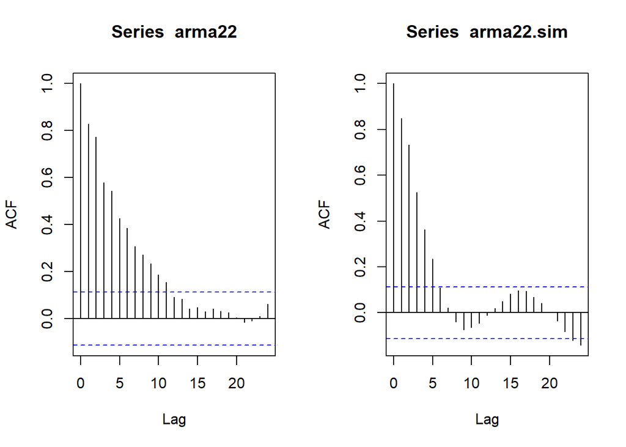

```r
par(mfrow = c(1, 2))
acf(arma22)
acf(arma22.sim)
```

Berdasarkan plot ACF tersebut, terlihat bahwa model ARMA(2,2) hasil simulasi memiliki plot ACF yang *tails off*, sesuai dengan teori yang ada

### Plot PACF

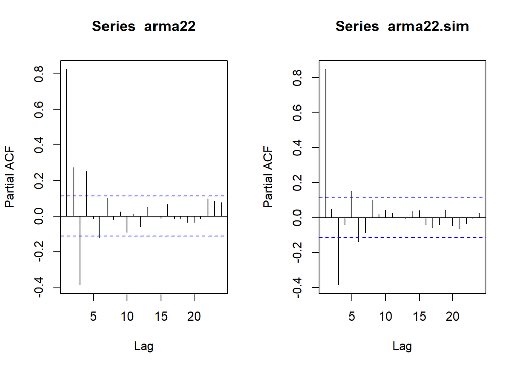

```r
par(mfrow = c(1, 2))
pacf(arma22)
pacf(arma22.sim)
```

Berdasarkan plot PACF tersebut, terlihat bahwa model ARMA(2,2) hasil simulasi memiliki plot PACF yang *tails off*, sesuai dengan teori dimana pola ACF/PACF seperti ini konsisten dengan proses ARMA **stasioner**.

Sesuai dengan teori pula, MA selalu stasioner dan bagian AR pada ARMA(2,2) dikatakan stastioner jika memenuhi 3 syarat:

$$\phi_{1}+\phi_{2}<1, \:\phi_{2}-\phi_{1}<1, \:dan
\:|\phi_{2}|<1$$

ARMA(2,2) dengan $\phi_1 = 0.5$ dan $\phi_2 = 0.2$ **memenuhi seluruh syarat** tersebut, sehingga data ini dapat dikatakan **stasioner**.

### Plot EACF

```r
TSA::eacf(arma22)
```

```
## AR/MA
##   0 1 2 3 4 5 6 7 8 9 10 11 12 13
## 0 x x x x x x x x x x x  o  o  o
## 1 x x x x x x o o o o x  x  o  x
## 2 x x o o o o o o o o o  o  o  o
## 3 x x o o o o o o o o o  o  o  o
## 4 o x o x o o o o o o o  o  o  o
## 5 o x o o o o o o o o o  o  o  o
## 6 x x o o o o o o o o o  x  o  o
## 7 x x x o o o o o o o o  o  o  o
```

```r
TSA::eacf(arma22.sim)
```

```
## AR/MA
##   0 1 2 3 4 5 6 7 8 9 10 11 12 13
## 0 x x x x x o o o o o o  o  o  o
## 1 o x o o x o o o x o o  o  o  o
## 2 x x x o x o o o o o o  o  o  o
## 3 o x x o x o o o o o o  o  o  o
## 4 x x x o x o o o o o o  o  o  o
## 5 x x x o o x o o o o o  o  o  o
## 6 x x o x o x o o o o o  o  o  o
## 7 x x o x x x o o x o o  o  o  o
```

Berdasarkan pola segitiga nol pada plot EACF data bangkitan manual, terlihat bahwa segitiga nol berada pada ordo **AR(2) dan ordo MA(2)**. Dan pada data bangkitan arima.sim segitiga nol berada pada ordo AR(2) dan MA(5). Pada data bangkitan arima.sim ada sedikit “noise” (muncul “x” di beberapa posisi lain), tapi itu wajar karena data sampel terbatas, bukan populasi.

### Autokorelasi Antar Lag

#### Korelasi antara $Y_t$ dengan $Y_{t-1}$

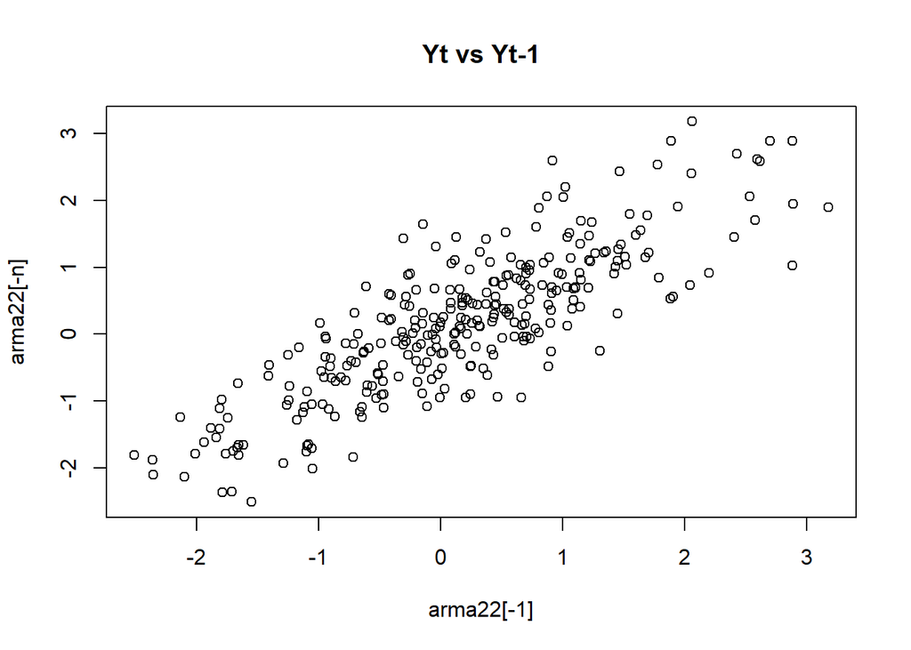

```r
plot(arma22[-1], arma22[-n], main="Yt vs Yt-1")
```

Berdasarkan scatterplot tersebut, terlihat bahwa terdapat hubungan positif antara $Y_t$ dengan $Y_{t-1}$. Hal ini sesuai dengan teori yang ada

```r
cor(arma22[-1],arma22[-n])
```

```
## [1] 0.8287681
```

Korelasi antara $Y_t$ dengan $Y_{t-1}$ dari hasil simulasi mendekati perhitungan teoritis dari hasil penurunan:

$$\rho_1 =
\frac{\psi_{0}\psi_{1}+\psi{1}\psi{2}+\dots}{\psi_{0}^2+\psi_{1}^2+\psi_{2}^2+\dots}
\:dimana \: \psi_{j}=\phi_{1}\psi_{j-1}+\phi_{2}\psi_{j-2}, \:j\ge3$$

$$\rho_1 = \frac{4.3009}{5.0043}=0.859$$

#### Korelasi antara $Y_t$ dan dengan $Y_{t-2}$

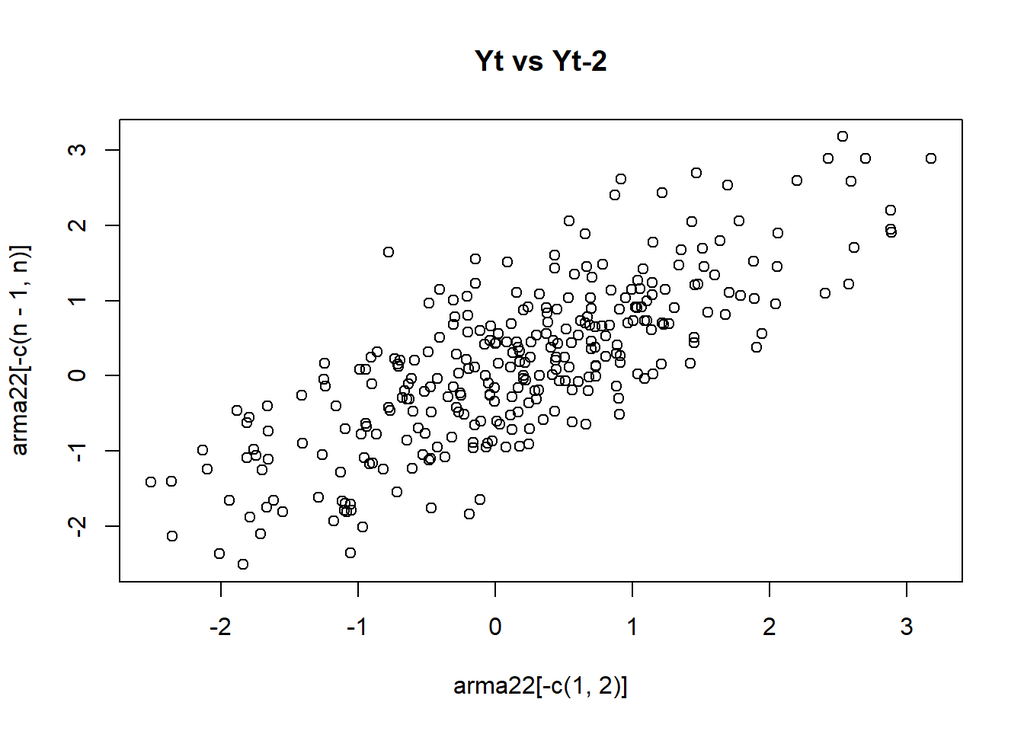

```r
plot(arma22[-c(1,2)], arma22[-c(n-1,n)], main="Yt vs Yt-2")
```

```r
cor(arma22[-c(1,2)],arma22[-c(n-1,n)])
```

```
## [1] 0.7727497
```

Korelasi antara $Y_t$ dengan $Y_{t-2}$ dari hasil simulasi mendekati perhitungan teoritis dari hasil penurunan:

$$\rho_2 =
\frac{\psi_{0}\psi_{2}+\psi{1}\psi{3}+\dots}{\psi_{0}^2+\psi_{1}^2+\psi_{2}^2+\dots}
\:dimana \: \psi_{j}=\phi_{1}\psi_{j-1}+\phi_{2}\psi_{j-2}, \:j\ge3$$

$$\rho_2 = \frac{3.7513}{5.0043}=0.749$$

#### Korelasi antara $Y_t$ dan dengan $Y_{t-3}$

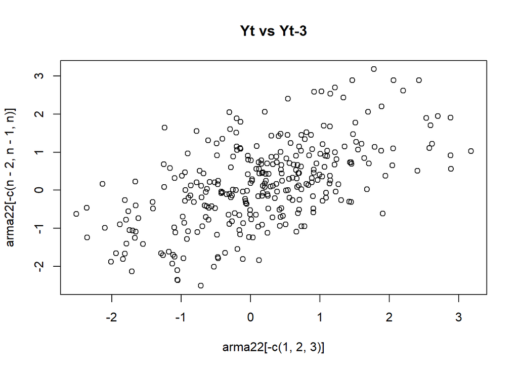

```r
plot(arma22[-c(1,2,3)], arma22[-c(n-2,n-1,n)], main="Yt vs Yt-3")
```

```r
cor(arma22[-c(1,2,3)],arma22[-c(n-2,n-1,n)])
```

```
## [1] 0.5792595
```

Korelasi antara $Y_t$ dengan $Y_{t-3}$ dari hasil simulasi mendekati perhitungan teoritis dari hasil penurunan:

$$\rho_3 =
\frac{\psi_{0}\psi_{3}+\psi{1}\psi{4}+\dots}{\psi_{0}^2+\psi_{1}^2+\psi_{2}^2+\dots}
\:dimana \: \psi_{j}=\phi_{1}\psi_{j-1}+\phi_{2}\psi_{j-2}, \:j\ge3$$

$$\rho_3 = \frac{2.7358}{5.0043}=0.546$$